# Pipeline for Analysis of Metabolomics Data in R

Ashkan Zareie

August-September 2017

Currently the pipeline encompasses the following steps:  
- Convert .d folders (Agilent proprietary format) to mzXML or mzML using MSConvert from the ProteoWizard toolbox  
- Use XCMS to analyze the data (pre-processing and univariate statistical analysis)  
- Use MetaboAnalyst.ca for multivariate data analysis

See these papers for some discussion on file formats:  
- https://doi.org/10.1016/j.jasms.2010.06.014  
- https://dx.doi.org/10.1007%2F978-1-60761-444-9_22  
- https://dx.doi.org/10.1074%2Fmcp.R110.000133

**PEAK PICKING METHOD**  
- ‘matchedfilter’ is used by default (when ‘xcmsSet’ method is used for loading data)  
- ‘centWave’ is commonly used for high resolution spectra/MS data  
- Irregardless of the peak picking method chosen, there are many parameters that can be tuned. The rule of thumb is, if you do not understand what a parameter exactly does, then it is best to use the default value.  
- “Mass deviation μ in ppm, typically set to a generous multiple of the mass accuracy of the mass spectrometer. We use μ = 30 ppm for the Bruker MicrOTOF-Q, which is advertised with a mass accuracy of 3–5 ppm”. (doi: 10.1186/1471-2105-9-504)  
- Q: How do we find the best tuning parameters for our dataset? (e.g. ‘fwhm’ specifies full width at half maximum (default is 30s) based on the type of chromatography)  
- Q: Is it a good idea to load all sample sets (Fresh, Frozen 24h, Frozen 1w) into one xcmsSet? To a high degree, this may not be a good idea, especially when samples are from different experiments

[output not shown]

```r
colnames(xset.pos@peaks)
```

```
##  [1] "mz"     "mzmin"  "mzmax"  "rt"     "rtmin"  "rtmax"  "into"
##  [8] "intb"   "maxo"   "sn"     "sample"
```

```r
dim(xset.pos@peaks)
```

```
## [1] 47137    11
```

- Grouping has its own methods too (density, mzClust, nearest)  
  Q: How do we tune grouping parameters? How do we find the best ones for our data?

```r
xsg.pos <- group(xset.pos)
```

```
## Processing 7585 mz slices ... OK
```

There are a few retention time correction methods in xcms: Gaussian, Symmetric, and Obiwarp.  
Plot shows the data points used for regression and the resulting deviation profiles. It can be used for supervising the algorithm. The distribution of peak groups across retention time is also shown in the plot.

```
## Performing retention time correction using 1552 peak groups.
```

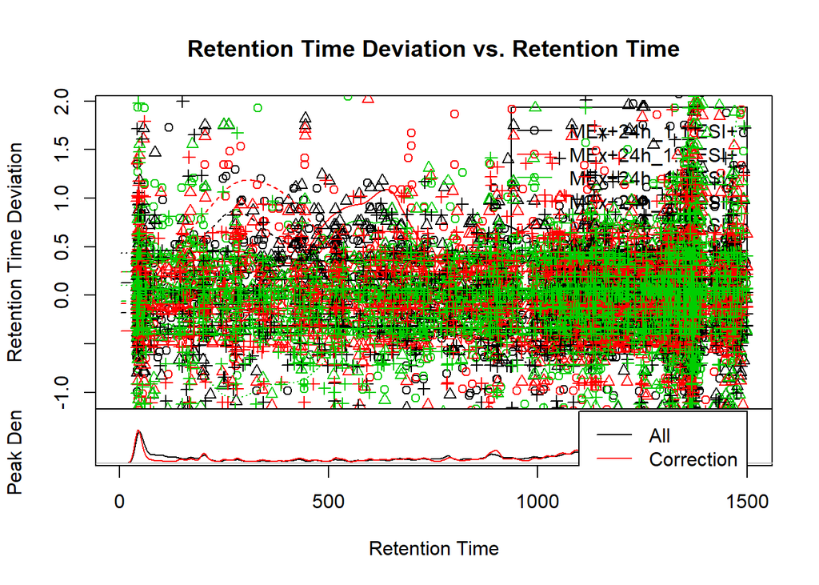

```r
xsg.pos.retcor.gaussian <- retcor(xsg.pos, family="gaussian", plottype="mdevden")
```

```r
#xsg.pos.retcor.symmetric <- retcor(xsg.pos, family="symmetric", plottype="mdevden")
#xsg.pos.retcor.obiwarp <- retcor.obiwarp(xsg.pos, plottype="deviation")
```

When re-grouping the retention time-corrected xset, parameters can also be re-tuned once more. For example, we can choose a narrower ‘bw’.

```r
xsg.gaus <- group(xsg.pos.retcor.gaussian)
```

```
## Processing 7585 mz slices ... OK
```

```r
#xsg.sym <- group(xsg.pos.retcor.symmetric, bw=10)
#xsg.obw <- group(xsg.pos.retcor.obiwarp, bw=10)
```

```r
xsg.gaus <- fillPeaks(xsg.gaus)
#xsg.sym <- fillPeaks(xsg.sym)
#xsg.obw <- fillPeaks(xsg.obw)
```

```r
peaks(xsg.gaus)[1:10,]
```

```
##             mz    mzmin    mzmax       rt    rtmin    rtmax     into
##  [1,] 150.9766 150.9752 150.9782 41.64184 38.53781 47.85071 5947.921
##  [2,] 248.9983 248.9970 248.9996 42.41740 38.53781 47.85071 2994.323
##  [3,] 334.8977 334.8895 334.9042 43.19401 38.53781 49.40380 3764.179
##  [4,] 424.7923 424.7829 424.7969 43.19401 38.53781 49.40380 5760.857
##  [5,] 206.0606 206.0580 206.0626 44.74633 39.31381 65.70437 5289.723
##  [6,] 220.9097 220.9076 220.9109 44.74633 38.53781 50.95587 4983.008
##  [7,] 285.9024 285.8994 285.9053 43.96966 37.76281 50.95587 4330.723
##  [8,] 426.7907 426.7883 426.7943 43.96966 38.53781 50.17934 9143.361
##  [9,] 510.8158 510.8080 510.8191 43.96966 39.31381 48.62726 3198.720
## [10,] 571.8811 571.8749 571.8844 43.96966 38.53781 50.17934 4165.901
##           intb      maxo   sn sample
##  [1,] 5939.390 2009.2006 2008      1
##  [2,] 2985.791  729.5873  729      1
##  [3,] 3754.871  924.0237  923      1
##  [4,] 5751.549 2225.1416 2224      1
##  [5,] 5250.046 1534.1761   52      1
##  [6,] 4972.149  946.1696  945      1
##  [7,] 4319.089  654.2722  653      1
##  [8,] 9133.279 4310.1807 4309      1
##  [9,] 3190.188  681.4073  680      1
## [10,] 4155.818  769.5817  769      1
```

```r
#peaks(xsg.sym)[1:10,]
#peaks(xsg.obw)[1:10,]
dim(xsg.gaus@peaks)
```

```
## [1] 56348    11
```

```r
dim(peaks(xsg.gaus)) ###Another way to do what was done in the previous line
```

```
## [1] 56348    11
```

‘diffreport’ computes Welch’s two-sample t-statistic for each analyte and ranks them by p-value. In brief, it performs univariate analysis on our peaks.  
Q: When using ‘diffreport’, it is possible to include three sample classes (or even many more) by defining the class1/class2 arguments as c(“sample2”,“sample3”). Does that, however, have any impact on the final result? In brief, is there a difference between `class1=c("Mouse1", "Mouse2"), class2="Mouse5"` and `(class1="Mouse1", class2=c( "Mouse2","Mouse5"))`

```r
rep.gaus <- diffreport(object=xsg.gaus, class1=c("Mouse1", "Mouse2"), class2="Mouse5", filebase="report", 50, metlin=0.15) ####quality of peaks can be inspected by checking the figures in report_eic folder
#rep.sym <- diffreport(xsg.sym, "Fresh", c("Frozen 1w", "Frozen 24h"), "Symmetric", 10, metlin=0.15)
#rep.obw <- diffreport(xsg.obw, "Fresh", c("Frozen 1w", "Frozen 24h"), "Obiwarp", 10, metlin=0.15)

rep.gaus[1:10,]
```

```
##         name      fold     tstat       pvalue        anova    mzmed
## 1    M116T50 11.080866  60.28411 5.170816e-09 1.534267e-08 116.1073
## 2  M536T1262  1.088912 -24.92887 1.684069e-07 9.101230e-06 536.2196
## 3   M286T685  2.229596 -18.54721 3.303003e-07 1.576607e-05 286.0791
## 4  M731T1360 83.933624 -26.40089 1.421381e-06 4.883383e-06 730.5405
## 5  M819T1287  1.409315 -15.07048 1.945932e-06 7.233000e-05 819.4112
## 6  M317T1012 12.081022 -13.79871 3.390388e-06 2.523365e-05 317.2291
## 7    M133T51  7.524614 -13.52919 4.626496e-06 2.494285e-04 133.0100
## 8   M177T119  4.749511  12.71671 5.322755e-06 1.090211e-07 177.1025
## 9   M488T927  1.108398 -13.53664 5.709752e-06 2.637630e-04 488.1093
## 10  M249T666  1.347292 -12.19460 5.711019e-06 3.630918e-04 249.1856
##       mzmin    mzmax      rtmed      rtmin      rtmax npeaks Mouse1 Mouse2
## 1  116.1073 116.1076   50.01900   49.68763   50.66329      6      3      3
## 2  536.2195 536.2199 1262.38429 1261.48419 1262.72766      9      3      3
## 3  286.0790 286.0792  684.84704  683.70797  685.18702      5      3      2
```

[output cut: 62 more lines]

```r
#rep.sym[1:10,]
#rep.obw[1:10,]
```

```r
#– Features (peaks) are in rows
#– Samples are in  columns
#– Group labels must be added by using 'phenoData'
#- If there are duplicated mzRT values in the rows of the generated peak intensity matrix, MetaboAnalyst will result in an error. To fix this error, simply distinguish repeated values by adding 'A', 'B', 'C', etc. to them. For example, if you have the mzRT feature 54.04/1499.3 twice in the resulting table, simply change the second one to 54.04/1499.3A
dat <- groupval(xsg.gaus, "medret", "into")
dat <- rbind(group = as.character(phenoData(xsg.gaus)$class), dat)
write.csv(dat, file='PeakIntensityMatrix_Fresh_and_FreshRerun.csv')
rm(dat)

#dat <- groupval(xsg.sym, "medret", "into")
#dat <- rbind(group = as.character(phenoData(xsg.sym)$class), dat)
#write.csv(dat, file='Symmetric_PeakIntensityMatrix.csv')
#rm(dat)

#dat <- groupval(xsg.obw, "medret", "into")
#dat <- rbind(group = as.character(phenoData(xsg.obw)$class), dat)
#write.csv(dat, file='Obiwarp_PeakIntensityMatrix.csv')
#rm(dat)
```

```r
#gt.gaus <- groups(xsg.gaus)
#gt.gaus[1:3,]

#gt.sym <- groups(xsg.sym)
#gt.sym[1:3,]

#gt.obw <- groups(xsg.obw)
#gt.obw[1:3,]

#grp_idx_gaus <- which(gt.gaus[,"rtmed"] > 0 & gt.gaus[,"rtmed"] < 500 & gt.gaus[,"npeaks"] > 50)[1]
#eiccor.gaus <- getEIC(xsg.gaus, groupidx=grp_idx_gaus)
#plot(eiccor.gaus, col=as.numeric(phenoData(xsg.gaus)$class))
```

Processing with peakML

```r
PeakML.xcms.write(xsg.gaus, filename = "xset.peakml")
```

```
## Retrieving peak index from peak table.
## MEx+24h_1.1 ESI+  MEx+24h_1.2 ESI+  MEx+24h_1.3 ESI+  MEx+24h_2.1 ESI+  MEx+24h_2.2 ESI+  MEx+24h_2.3 ESI+  MEx+24h_5.1 ESI+  MEx+24h_5.2 ESI+  MEx+24h_5.3 ESI+
## retrieving raw data
## - C:/r/Freezing_Experiment/pos/Frozen/Mouse1/MEx+24h_1.1 ESI+.mzXML
```

```
## Create profile matrix with method 'bin' and step 1 ... OK
```

```
## - C:/r/Freezing_Experiment/pos/Frozen/Mouse1/MEx+24h_1.2 ESI+.mzXML
```

```
## Create profile matrix with method 'bin' and step 1 ... OK
```

```
## - C:/r/Freezing_Experiment/pos/Frozen/Mouse1/MEx+24h_1.3 ESI+.mzXML
```

```
## Create profile matrix with method 'bin' and step 1 ... OK
```

```
## - C:/r/Freezing_Experiment/pos/Frozen/Mouse2/MEx+24h_2.1 ESI+.mzXML
```

```
## Create profile matrix with method 'bin' and step 1 ... OK
```

```
## - C:/r/Freezing_Experiment/pos/Frozen/Mouse2/MEx+24h_2.2 ESI+.mzXML
```

```
## Create profile matrix with method 'bin' and step 1 ... OK
```

```
## - C:/r/Freezing_Experiment/pos/Frozen/Mouse2/MEx+24h_2.3 ESI+.mzXML
```

```
## Create profile matrix with method 'bin' and step 1 ... OK
```

```
## - C:/r/Freezing_Experiment/pos/Frozen/Mouse5/MEx+24h_5.1 ESI+.mzXML
```

```
## Create profile matrix with method 'bin' and step 1 ... OK
```

```
## - C:/r/Freezing_Experiment/pos/Frozen/Mouse5/MEx+24h_5.2 ESI+.mzXML
```

```
## Create profile matrix with method 'bin' and step 1 ... OK
```

```
## - C:/r/Freezing_Experiment/pos/Frozen/Mouse5/MEx+24h_5.3 ESI+.mzXML
```

```
## Create profile matrix with method 'bin' and step 1 ... OK
```

```
## 758 mass chromatograms of length <3 are removed
## 43126 mass chromatograms extracted
```

```r
PeakML.Viewer()
```

```
## OS type: x86_64-w64-mingw32
```

```r
###Load xset.peakml generated in the previous step
```

— Secondary pipeline / secondary approach to analysis —  
This is currently only used to generate BPC and TIC plots  
MSnbase is used to load the data, but at the core of the pipeline xcms is used to do everything else.

```r
path.pos <- "C:/r/Freezing_Experiment/pos/Frozen"
pos.mzxml <- list.files(path.pos, recursive = T, full.names = T, pattern=".mzXML")

## phenodata
s_groups <- rep("Mouse1", length(pos.mzxml))
s_groups[grep(pos.mzxml, pattern = "Mouse2")] <- "Mouse2"
s_groups[grep(pos.mzxml, pattern = "Mouse5")] <- "Mouse5"

## Define a data.frame that can be used as phenodata
pheno <- data.frame(sample_name = sub(basename(pos.mzxml), pattern = ".mzXML", replacement = "", fixed = TRUE),
                    sample_group = s_groups, stringsAsFactors = FALSE)

MSn.set.exp <- readMSData2(pos.mzxml, pdata = new("NAnnotatedDataFrame", pheno))
rtime(MSn.set.exp[[1]]) ### retention time of the first spectrum
```

```
## [1] 2.992
```

```r
rtime(MSn.set.exp[[100]]) ### retention time of the 100th spectrum
```

```
## [1] 79.774
```

```r
mz(MSn.set.exp[[1]]) ### mz values of the first spectrum
```

```
##  [1]  97.02841 100.07562 103.95602 104.10760 105.95406 107.05003 112.05041
##  [8] 113.05560 113.07115 113.10727 113.96415 114.06567 114.09104 114.11107
## [15] 115.95993 116.06885 118.08624 118.12296 119.08999 120.10080 121.05087
## [22] 121.95758 122.05472 122.08249 123.05580 123.95524 124.04009 126.05496
## [29] 127.03910 127.05008 128.07067 128.95288 129.10238 131.11786 134.08126
## [36] 134.94265 136.06199 136.93809 137.04524 139.05193 144.98279 145.04983
## [43] 146.09300 146.98043 148.09684 149.02418 150.05634 150.11235 152.05698
## [50] 152.09314 158.11727 166.07249 168.06484 169.13420 170.11857 174.08870
## [57] 178.10791 178.12379 180.08702 180.10172 186.07644 190.94361 191.94140
## [64] 194.11793 195.12156 198.09712 198.12460 202.17953 204.08688 210.10936
## [71] 216.17171 217.15508 222.11119 224.12706 229.15390 230.09461 231.16942
## [78] 235.16771 243.17061 244.17396 252.14475 253.14907 255.09685 257.11391
## [85] 258.11252 260.16242 261.18128 276.10868 316.11648 317.11919 318.11188
## [92] 319.11490 346.12635 399.14446 922.00980 923.01110 924.01400
```

```r
head(mz(MSn.set.exp[[1]]))
```

```
## [1]  97.02841 100.07562 103.95602 104.10760 105.95406 107.05003
```

```r
head(intensity(MSn.set.exp[[1]]))
```

```
## [1] 265.5091 421.8708 681.4943 848.2064 295.3480 221.6735
```

```r
intensity(MSn.set.exp[[1]]) ### intensity values of the first spectrum
```

```
##  [1]   265.5091   421.8708   681.4943   848.2064   295.3480   221.6735
##  [7]  2933.1238   206.9626   229.7290  4181.1216   322.3517   336.9009
## [13]   367.6449   307.9397  1475.0319   290.4986  6489.1104   250.2970
## [19]   286.8662   208.4000 20903.5879   285.6823   849.0927   270.9261
## [25]   803.2299   289.1578   480.2776   213.2592   408.9670   271.8758
## [31]   667.1146   276.2434  2152.4355   555.1437   224.6021   246.8802
## [37]  1353.5166   225.5031   381.5041   403.5376   929.1641   368.0678
## [43]   549.4236   328.0465   307.1747   362.6413   464.3852   206.2292
## [49]  1690.1249   473.8931   274.2470   797.6673   344.2297   321.7969
## [55]   491.4416   471.3084   387.2014   205.7193   258.0016   224.0853
## [61]   260.7813   234.7536   294.3362  3992.7732   310.4453   240.1239
## [67]   677.2866   255.9804   314.8789   259.9258   373.5217   642.2092
## [73]   443.9767   263.4091   318.6758   305.6235   225.5391   216.3056
## [79]  1853.7289   344.0500  5712.3252   709.5648   366.5265   355.6667
## [85]   207.6123   364.1023   219.5156   252.3750  1417.3983   283.0381
## [91]   519.4295   247.7314   400.7480   234.7500 23503.9219  3255.1118
## [97]   383.2780
```

```r
head(tic(MSn.set.exp)) ### the total ion current, as reported in the original raw data file
```

```
## F1.S0001 F1.S0002 F1.S0003 F1.S0004 F1.S0005 F1.S0006
## 111598.9 109464.8 112704.6 113218.8 114714.5 116806.8
```

```r
head(fromFile(MSn.set.exp)) ### fromFile method returns the index of the file that the spectrum originates from.
```

```
## F1.S0001 F1.S0002 F1.S0003 F1.S0004 F1.S0005 F1.S0006
##        1        1        1        1        1        1
```

```r
fromFile(MSn.set.exp[[15000]]) ### index of the file containing the 15000th spectrum
```

```
## [1] 8
```

```r
#MSnbase::plot(MSn.set.exp[[5000]]) ### plotting the 5000th spectrum
```

```r
## Extract the TIC (Total Ion Current) and retention times, and split them by file.
tics <- split(tic(MSn.set.exp), f = fromFile(MSn.set.exp))
rts <- split(rtime(MSn.set.exp), f = fromFile(MSn.set.exp))

## Define the color for each sample
sample_colors <- brewer.pal(3, "Set1")[1:3]
names(sample_colors) <- unique(s_groups)
cols <- paste0(sample_colors[pData(MSn.set.exp)$sample_group], 80)

exp.polarity <- as.character()
if(gsub("^.*/","",dirname(path.pos[1])) == "pos") {exp.polarity <- "ESI+"}
if(gsub("^.*/","",dirname(path.pos[1])) == "neg") {exp.polarity <- "ESI-"}
pdf(paste0("TIC_Plot_", basename(path.pos[[1]]), "_", exp.polarity, ".pdf"))
plot(3, 3, pch = NA, xlim = range(rts), ylim = range(tics), main = paste0("Total Ion Current (", basename(path.pos[[1]]), " ", exp.polarity, " samples)"),
     xlab = "RT (retention time)", ylab = "intensity")
tmp <- mapply(rts, tics, cols, FUN = function(x, y, col) {
    points(x = x, y = y, col = col, type = "l")
})
legend("topleft", col = sample_colors, legend = names(sample_colors), lty = 1)
dev.off()
```

```r
chrs <- extractChromatograms(MSn.set.exp, aggregationFun = "max")
```

```r
pdf(paste0("BPC_Plot_", basename(path.pos[[1]]), "_", exp.polarity, ".pdf"))
plotChromatogram(
    chrs,
    col = paste0(sample_colors[pData(MSn.set.exp)$sample_group], 80), main=paste0("Base Peak Chromatogram (", basename(path.pos[[1]]), " ", exp.polarity, " samples)"))
legend("topleft", col = sample_colors, legend = names(sample_colors), lty = 1)
dev.off()
```

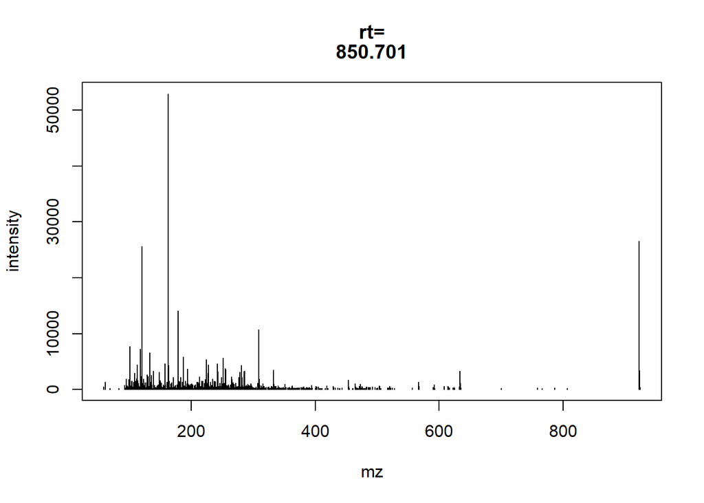

```r
subs <- filterFile(filterRt(MSn.set.exp, rt = c(850,900)), file = 1) ### choose file and rt range

## Extract the Spectrum
spctr <- spectra(subs)[[1]]
plot(mz(spctr), intensity(spctr), type = "h", xlab = "mz", ylab = "intensity", main=c("rt=", spctr@rt))
```

peaks intensities are in columns  
“into” (integrated peak signal)  
“maxo” (maximum signal at the peak’s apex)

```r
cwp <- CentWavePredIsoParam(ppm=30)
msn.chpeaks <- findChromPeaks(MSn.set.exp, param = cwp)
```

[output not shown]

[output not shown]

```r
msn.chpeaks
```

```
## MSn experiment data ("XCMSnExp")
## Object size in memory: 3.48 Mb
## - - - Spectra data - - -
##  MS level(s): 1
##  Number of spectra: 17372
##  MSn retention times: 0:3 - 24:60 minutes
## - - - Processing information - - -
## Data loaded [Fri Oct 13 10:57:25 2017]
##  MSnbase version: 2.3.11
## - - - Meta data  - - -
## phenoData
##   rowNames: 1 2 ... 9 (9 total)
##   varLabels: sample_name sample_group
##   varMetadata: labelDescription
## Loaded from:
##   [1] MEx+24h_1.1 ESI+.mzXML...  [9] MEx+24h_5.3 ESI+.mzXML
##   Use 'fileNames(.)' to see all files.
## protocolData: none
## featureData
##   featureNames: F1.S0001 F1.S0002 ... F9.S1930 (17372 total)
##   fvarLabels: fileIdx spIdx ... spectrum (26 total)
##   fvarMetadata: labelDescription
## experimentData: use 'experimentData(object)'
## - - - xcms preprocessing - - -
## Chromatographic peak detection:
##  method: centWave
##  47137 peaks identified in 9 samples.
##  On average 5237 chromatographic peaks per sample.
```

```r
head(chromPeaks(msn.chpeaks))
```

```
##            mz    mzmin    mzmax     rt  rtmin  rtmax     into     intb
## [1,] 150.9766 150.9752 150.9782 41.771 38.668 47.975 5947.921 5939.390
## [2,] 248.9983 248.9970 248.9996 42.546 38.668 47.975 2994.323 2985.791
## [3,] 334.8977 334.8895 334.9042 43.322 38.668 49.527 3764.179 3754.871
## [4,] 424.7923 424.7829 424.7969 43.322 38.668 49.527 5760.857 5751.549
## [5,] 206.0606 206.0580 206.0626 44.873 39.444 65.814 5289.723 5250.046
## [6,] 220.9097 220.9076 220.9109 44.873 38.668 51.078 4983.008 4972.149
##           maxo   sn sample is_filled
## [1,] 2009.2006 2008      1         0
## [2,]  729.5873  729      1         0
## [3,]  924.0237  923      1         0
## [4,] 2225.1416 2224      1         0
## [5,] 1534.1761   52      1         0
## [6,]  946.1696  945      1         0
```

```r
detected.peaks <- chromPeaks(msn.chpeaks)
table(detected.peaks[,"sample"]) ###Number of peaks per sample
```

```
##
##    1    2    3    4    5    6    7    8    9
## 5432 5627 5586 5260 5291 5301 5050 4815 4775
```

```r
table(detected.peaks[,"sample"])/sum(detected.peaks[,"sample"])
```

```
##
##          1          2          3          4          5          6
## 0.02365957 0.02450891 0.02433033 0.02291041 0.02304543 0.02308898
##          7          8          9
## 0.02199573 0.02097217 0.02079794
```

```r
chromPeaks(msn.chpeaks, mz = 316.1165)
```

```
##             mz    mzmin    mzmax       rt    rtmin    rtmax       into
##  [1,] 316.1127 316.1118 316.1194   51.853   35.566   69.691   43178.58
##  [2,] 316.1162 316.1145 316.1178  172.844  139.494  203.867   44048.24
##  [3,] 316.1176 316.1136 316.1199 1021.330  977.896 1065.540   64327.47
##  [4,] 734.5717   0.0000 734.5722 1427.730 1419.200 1444.020 2856233.02
##  [5,] 316.1163 316.1142 316.1187  171.861  117.570  212.967   67297.52
##  [6,] 316.1164 316.1153 316.1173   52.420   33.807   77.240   55572.85
##  [7,] 316.1055 316.0937 316.1191 1031.200 1000.960 1060.680   71780.13
##  [8,] 316.1124 316.1116 316.1186   52.437   36.150   70.275   55303.30
##  [9,] 316.1164 316.1145 316.1180  173.427  109.054  205.226   68530.92
## [10,] 316.1129 316.1110 316.1186   52.828   37.317   69.892   35539.91
## [11,] 316.1163 316.1143 316.1178  172.268  142.020  203.291   44514.07
## [12,] 316.1068 316.0934 316.1187 1030.830  999.036 1061.080   66104.83
## [13,] 734.5718   0.0000 734.5725 1427.930 1419.400 1444.220 3010952.43
## [14,] 316.1128 316.1113 316.1182   53.494   37.207   70.557   39740.54
```

[output cut: 53 more lines]

```r
chrs <- extractChromatograms(msn.chpeaks, mz = 316.1165, rt = 2.992)
```

```r
#plotChromatogram(chrs,
#         col = paste0(sample_colors[pData(msn.chpeaks)$sample_group], 80))
#highlightChromPeaks(
#    msn.chpeaks, rt = 2.992, mz = 316.1165,
#    border = paste0(sample_colors[pData(msn.chpeaks)$sample_group], 40))
```

```r
msn.rt <- adjustRtime(msn.chpeaks, param = ObiwarpParam())
```

```
## Sample number 5 used as center sample.
```

```
## Aligning MEx+24h_1.1 ESI+.mzXML against MEx+24h_2.2 ESI+.mzXML ... OK
## Aligning MEx+24h_1.2 ESI+.mzXML against MEx+24h_2.2 ESI+.mzXML ... OK
## Aligning MEx+24h_1.3 ESI+.mzXML against MEx+24h_2.2 ESI+.mzXML ... OK
## Aligning MEx+24h_2.1 ESI+.mzXML against MEx+24h_2.2 ESI+.mzXML ... OK
```

```
## Aligning MEx+24h_2.3 ESI+.mzXML against MEx+24h_2.2 ESI+.mzXML ... OK
## Aligning MEx+24h_5.1 ESI+.mzXML against MEx+24h_2.2 ESI+.mzXML ... OK
## Aligning MEx+24h_5.2 ESI+.mzXML against MEx+24h_2.2 ESI+.mzXML ... OK
## Aligning MEx+24h_5.3 ESI+.mzXML against MEx+24h_2.2 ESI+.mzXML ... OK
```

```
## Applying retention time adjustment to the identified chromatographic peaks ... OK
```

```r
hasAdjustedRtime(msn.rt)
```

```
## [1] TRUE
```

```r
head(rtime(msn.rt)) ###Adjusted retention times
```

```
## F1.S0001 F1.S0002 F1.S0003 F1.S0004 F1.S0005 F1.S0006
## 3.082000 3.857011 4.633021 5.408031 6.184042 6.960051
```

```r
head(rtime(msn.rt, adjusted = FALSE)) ###Raw retention times
```

```
## F1.S0001 F1.S0002 F1.S0003 F1.S0004 F1.S0005 F1.S0006
##    2.992    3.767    4.543    5.318    6.094    6.870
```

```r
####grouping of chromatographic peaks within and between samples.
msn.rt.g <- groupChromPeaks(msn.rt, param = PeakDensityParam())
```

```
## Empty 'sampleGroups' in 'param', assuming all samples to be in the same group.
## Processing 7585 mz slices ... OK
```

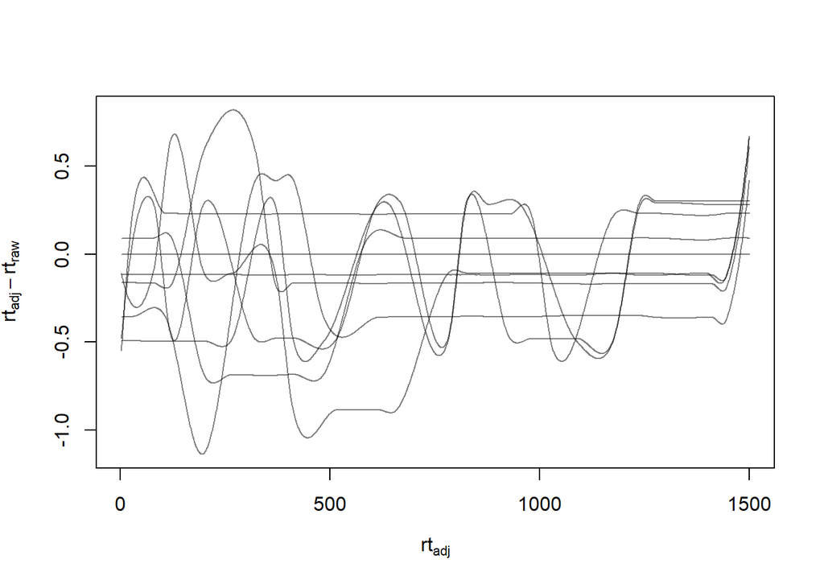

```r
plotAdjustedRtime(msn.rt.g)
```

```r
chrs <- extractChromatograms(msn.rt.g, aggregationFun = "max")
```

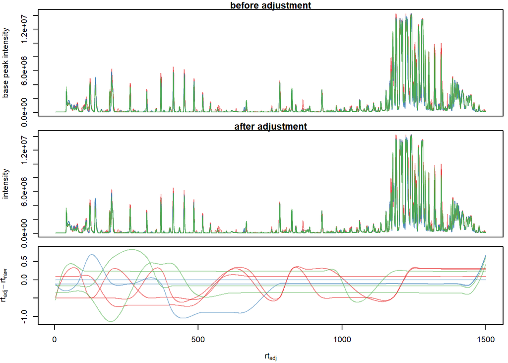

```r
rt_raw <- rtime(msn.rt.g, adjusted = FALSE, bySample = TRUE)
ints <- lapply(chrs, intensity)
par(mfrow = c(3, 1), mar = c(0.5, 4, 1, 0.5))
plot(3, 3, pch = NA, xlab = "", ylab = "base peak intensity", xaxt = "n",
     main = "before adjustment", xlim = range(rt_raw), ylim = range(ints))
cols <- paste0(sample_colors[pData(msn.rt.g)$sample_group], 80)
tmp <- mapply(rt_raw, ints, cols, FUN = function(x, y, col) {
    points(x, y, col = col, type = "l")
})
plotChromatogram(chrs, main = "after adjustment", col = cols, xaxt = "n")
par(mar = c(4, 4, 0.5, 0.5))
plotAdjustedRtime(msn.rt.g, col = cols)
```

```r
head(featureValues(msn.rt.g, value = "into"))
```

```
##        MEx+24h_1.1 ESI+.mzXML MEx+24h_1.2 ESI+.mzXML
## FT0001              39560.763              42126.337
## FT0002              11774.389               9895.121
## FT0003               6042.356               8133.123
## FT0004              43506.513              40612.535
## FT0005              45761.899                     NA
## FT0006                     NA              46909.049
##        MEx+24h_1.3 ESI+.mzXML MEx+24h_2.1 ESI+.mzXML
## FT0001              57178.316               47385.63
## FT0002               9835.967               11287.37
## FT0003               3766.713                     NA
## FT0004              36301.943               37735.18
## FT0005              45113.647               43014.16
## FT0006              35276.262               31418.91
##        MEx+24h_2.2 ESI+.mzXML MEx+24h_2.3 ESI+.mzXML
## FT0001              42415.355               45866.55
## FT0002                     NA                     NA
## FT0003               4843.764                     NA
## FT0004              50531.835               54470.04
## FT0005                     NA               56246.93
## FT0006              38664.692               28061.19
##        MEx+24h_5.1 ESI+.mzXML MEx+24h_5.2 ESI+.mzXML
## FT0001                     NA                     NA
## FT0002              10370.824               14324.44
## FT0003               3721.459                     NA
## FT0004              40279.663               44620.25
## FT0005              51855.305               55665.09
## FT0006              30060.860                     NA
##        MEx+24h_5.3 ESI+.mzXML
## FT0001                     NA
## FT0002              13205.242
## FT0003               4118.056
## FT0004              46871.242
## FT0005              38161.958
## FT0006              31435.847
```

```r
msn.rt.g <- fillChromPeaks(msn.rt.g)
```

```
## Requesting 380 missing peaks from MEx+24h_1.1 ESI+.mzXML ... got 366.
## Requesting 345 missing peaks from MEx+24h_1.2 ESI+.mzXML ... got 341.
## Requesting 357 missing peaks from MEx+24h_1.3 ESI+.mzXML ... got 341.
## Requesting 447 missing peaks from MEx+24h_2.1 ESI+.mzXML ... got 432.
```

```
## Requesting 411 missing peaks from MEx+24h_2.2 ESI+.mzXML ... got 402.
## Requesting 375 missing peaks from MEx+24h_2.3 ESI+.mzXML ... got 366.
## Requesting 526 missing peaks from MEx+24h_5.1 ESI+.mzXML ... got 507.
## Requesting 612 missing peaks from MEx+24h_5.2 ESI+.mzXML ... got 589.
## Requesting 600 missing peaks from MEx+24h_5.3 ESI+.mzXML ... got 578.
```

```r
head(featureValues(msn.rt.g, value = "into"))
```

```
##        MEx+24h_1.1 ESI+.mzXML MEx+24h_1.2 ESI+.mzXML
## FT0001              39560.763              42126.337
## FT0002              11774.389               9895.121
## FT0003               6042.356               8133.123
## FT0004              43506.513              40612.535
## FT0005              45761.899              44810.013
## FT0006              59604.545              46909.049
##        MEx+24h_1.3 ESI+.mzXML MEx+24h_2.1 ESI+.mzXML
## FT0001              57178.316              47385.629
## FT0002               9835.967              11287.368
## FT0003               3766.713               1614.769
## FT0004              36301.943              37735.181
## FT0005              45113.647              43014.156
## FT0006              35276.262              31418.915
##        MEx+24h_2.2 ESI+.mzXML MEx+24h_2.3 ESI+.mzXML
## FT0001              42415.355              45866.554
## FT0002              11093.385              10037.433
## FT0003               4843.764               2199.896
## FT0004              50531.835              54470.036
## FT0005              43043.758              56246.927
## FT0006              38664.692              28061.187
##        MEx+24h_5.1 ESI+.mzXML MEx+24h_5.2 ESI+.mzXML
## FT0001              48443.427              47302.569
## FT0002              10370.824              14324.439
## FT0003               3721.459               2579.868
## FT0004              40279.663              44620.249
## FT0005              51855.305              55665.086
## FT0006              30060.860              27494.103
##        MEx+24h_5.3 ESI+.mzXML
## FT0001              39357.426
## FT0002              13205.242
## FT0003               4118.056
## FT0004              46871.242
## FT0005              38161.958
## FT0006              31435.847
```

```r
featureDefinitions(msn.rt.g)
```

```
## DataFrame with 3993 rows and 9 columns
##            mzmed     mzmin     mzmax      rtmed     rtmin      rtmax
##        <numeric> <numeric> <numeric>  <numeric> <numeric>  <numeric>
## FT0001  56.04930  56.04925  56.04946   58.85196   58.1480   59.72018
## FT0002  57.06937  57.06929  57.06943 1077.27466 1077.2599 1078.04041
## FT0003  57.03301  57.03289  57.03333  727.47409  726.9068  728.24854
## FT0004  59.04873  59.04863  59.04878  898.10095  897.3258  898.10992
## FT0005  59.04870  59.04865  59.04878  784.86694  784.1133  785.64209
## ...          ...       ...       ...        ...       ...        ...
## FT3989  988.5301  988.5294  988.5310   1457.302  1456.520   1458.071
## FT3990  988.9239  988.9235  988.9260   1370.419  1369.650   1373.519
## FT3991  989.5335  989.4845  989.5374   1457.301  1379.729   1458.072
## FT3992  989.9281  989.9276  989.9342   1368.870  1368.089   1371.210
## FT3993  990.5578  990.5506  990.5587   1427.818  1427.013   1458.070
##           npeaks        X1               peakidx
##        <numeric> <numeric>                <list>
## FT0001         6         6    275,5770,11440,...
## FT0002         7         7   2292,7765,13446,...
## FT0003         6         6   1405,6845,12580,...
## FT0004         9         9   1801,7278,12979,...
## FT0005         7         7  1800,12978,18412,...
## ...          ...       ...                   ...
## FT3989         5         5  4260,15539,36528,...
## FT3990         5         5 10643,15094,21516,...
## FT3991         7         6  4249,15536,20841,...
## FT3992         5         5  3865,10624,36055,...
## FT3993        10         8    4186,9761,9869,...
```

```r
pdf(paste0(basename(path.pos[[1]]), "_", exp.polarity, "_Peakimage.pdf"))
plotChromPeakImage(msn.rt.g) ####This function plots the number of detected peaks for each sample along the retention time axis as an image plot, i.e. with the number of peaks detected in each bin along the retention time represented with the color of the respective cell.
for(i in 1:length(fileNames(msn.rt.g))){
plotChromPeaks(msn.rt.g, file=i)
}
dev.off()
```

```r
#mzr <- c(89.96725, 90.05811)
#chrs <- extractChromatograms(msn.chpeaks, mz = mzr, rt = c(500, 600))
#cols <- brewer.pal(3, "Set1")[c(1, 1, 2, 2)]
#plotChromatogram(chrs, col = paste0(cols, 80))

#chrs_adj <- extractChromatograms(msn.rt.g, mz = mzr, rt = c(500, 600))
#par(mfrow = c(2, 1))
#plot(chrs, col = paste0(cols, 80), main = "Before alignment")
#plot(chrs_adj, col = paste0(cols, 80), main = "After alignment")
```

```r
#####This section is currently under construction (apLCMS might not be as reliable as xcms)
#apLCMS.set <- apLCMS::cdf.to.ftr(path.pos, file.pattern = ".mzXML")
```